# R 고급 통계분석 2일차 (4)

## R 프로그램

```r
setwd("C:/Users/stats/Documents/advanced2")
app <- read.table("Applicant.TXT", header = T)
head(app)
```

```
##   ID X1.FL. X2.APP. X3.AA. X4.LA. X5.SC. X6.LC. X7.HON. X8.SMS. X9.EXP.
## 1  1      6       7      2      5      8      7       8       8       3
## 2  2      9      10      5      8     10      9       9      10       5
## 3  3      7       8      3      6      9      8       9       7       4
## 4  4      5       6      8      5      6      5       9       2       8
## 5  5      6       8      8      8      4      4       9       5       8
## 6  6      7       7      7      6      8      7      10       5       9
##   X10.DRV. X11.AMB. X12.GSP. X13.POT. X14.KJ. X15.SUIT.
## 1        8        9        7        5       7        10
## 2        9        9        8        8       8        10
## 3        9        9        8        6       8        10
## 4        4        5        8        7       6         5
## 5        5        5        8        8       7         7
## 6        6        5        8        6       6         6
```

```r
app <- app[,-1]   # ID 제거

library(psych)
describe(app)
```

```
##           vars  n mean   sd median trimmed  mad min max range  skew kurtosis
## X1.FL.       1 48 6.00 2.67    6.0    6.10 2.97   0  10    10 -0.24    -0.81
## X2.APP.      2 48 7.08 1.97    7.0    7.22 1.48   3  10     7 -0.74    -0.29
## X3.AA.       3 48 7.08 1.99    7.0    7.18 1.48   2  10     8 -0.37    -0.46
## X4.LA.       4 48 6.15 2.81    7.0    6.35 2.97   0  10    10 -0.60    -0.56
## X5.SC.       5 48 6.94 2.42    8.0    7.12 1.48   1  10     9 -0.72    -0.55
## X6.LC.       6 48 6.31 3.17    8.0    6.58 2.97   0  10    10 -0.63    -0.89
## X7.HON.      7 48 8.04 2.53    9.0    8.53 1.48   0  10    10 -1.72     2.50
## X8.SMS.      8 48 4.85 3.44    4.5    4.82 3.71   0  10    10  0.17    -1.35
## X9.EXP.      9 48 4.23 3.31    3.0    4.08 2.97   0  10    10  0.56    -1.12
## X10.DRV.    10 48 5.31 2.95    5.0    5.28 4.45   0  10    10  0.11    -1.29
## X11.AMB.    11 48 5.98 2.94    6.0    6.10 4.45   0  10    10 -0.22    -1.08
## X12.GSP.    12 48 6.25 3.04    7.0    6.50 2.22   0  10    10 -0.77    -0.52
## X13.POT.    13 48 5.69 3.18    6.0    5.82 2.97   0  10    10 -0.49    -1.01
## X14.KJ.     14 48 5.56 2.66    5.0    5.68 2.97   0  10    10 -0.27    -0.28
## X15.SUIT.   15 48 5.96 3.30    6.0    6.15 4.45   0  10    10 -0.24    -1.24
##             se
## X1.FL.    0.39
## X2.APP.   0.28
## X3.AA.    0.29
## X4.LA.    0.40
## X5.SC.    0.35
## X6.LC.    0.46
## X7.HON.   0.37
## X8.SMS.   0.50
## X9.EXP.   0.48
## X10.DRV.  0.43
## X11.AMB.  0.42
## X12.GSP.  0.44
## X13.POT.  0.46
## X14.KJ.   0.38
## X15.SUIT. 0.48
```

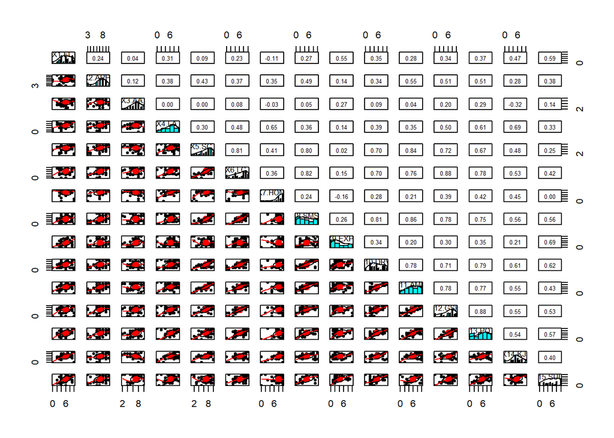

```r
pairs.panels(app)
```

```r
app_s <- scale(app)

fa1 <- factanal(app_s, 4)        # cor
print(fa1, digits = 2, sort = T)
```

```
##
## Call:
## factanal(x = app_s, factors = 4)
##
## Uniquenesses:
##    X1.FL.   X2.APP.    X3.AA.    X4.LA.    X5.SC.    X6.LC.   X7.HON.   X8.SMS.
##      0.44      0.68      0.52      0.18      0.12      0.20      0.34      0.14
##   X9.EXP.  X10.DRV.  X11.AMB.  X12.GSP.  X13.POT.   X14.KJ. X15.SUIT.
##      0.36      0.23      0.14      0.15      0.09      0.00      0.25
##
## Loadings:
##           Factor1 Factor2 Factor3 Factor4
## X5.SC.     0.92            0.14
## X6.LC.     0.84    0.11    0.29
## X8.SMS.    0.88    0.26
## X10.DRV.   0.77    0.39    0.17
## X11.AMB.   0.90    0.18
## X12.GSP.   0.79    0.28    0.35    0.15
## X13.POT.   0.74    0.35    0.43    0.25
## X1.FL.     0.13    0.72    0.11   -0.12
## X9.EXP.            0.78            0.17
## X15.SUIT.  0.36    0.77            0.14
## X4.LA.     0.23    0.24    0.84
## X7.HON.    0.25   -0.22    0.74
## X3.AA.             0.13            0.68
## X14.KJ.    0.42    0.39    0.55   -0.60
## X2.APP.    0.46    0.14    0.24    0.16
##
##                Factor1 Factor2 Factor3 Factor4
## SS loadings       5.57    2.47    2.10    1.01
## Proportion Var    0.37    0.16    0.14    0.07
## Cumulative Var    0.37    0.54    0.68    0.74
##
## Test of the hypothesis that 4 factors are sufficient.
## The chi square statistic is 84 on 51 degrees of freedom.
## The p-value is 0.00247
```

```r
fa2 <- factanal(app, 4)          # cov
print(fa2, digits = 2, sort = T)
```

```
##
## Call:
## factanal(x = app, factors = 4)
##
## Uniquenesses:
##    X1.FL.   X2.APP.    X3.AA.    X4.LA.    X5.SC.    X6.LC.   X7.HON.   X8.SMS.
##      0.44      0.68      0.52      0.18      0.12      0.20      0.34      0.14
##   X9.EXP.  X10.DRV.  X11.AMB.  X12.GSP.  X13.POT.   X14.KJ. X15.SUIT.
##      0.36      0.23      0.14      0.15      0.09      0.00      0.25
##
## Loadings:
##           Factor1 Factor2 Factor3 Factor4
## X5.SC.     0.92            0.14
## X6.LC.     0.84    0.11    0.29
## X8.SMS.    0.88    0.26
## X10.DRV.   0.77    0.39    0.17
## X11.AMB.   0.90    0.18
## X12.GSP.   0.79    0.28    0.35    0.15
## X13.POT.   0.74    0.35    0.43    0.25
## X1.FL.     0.13    0.72    0.11   -0.12
## X9.EXP.            0.78            0.17
## X15.SUIT.  0.36    0.77            0.14
## X4.LA.     0.23    0.24    0.84
## X7.HON.    0.25   -0.22    0.74
## X3.AA.             0.13            0.68
## X14.KJ.    0.42    0.39    0.55   -0.60
## X2.APP.    0.46    0.14    0.24    0.16
##
##                Factor1 Factor2 Factor3 Factor4
## SS loadings       5.57    2.47    2.10    1.01
## Proportion Var    0.37    0.16    0.14    0.07
## Cumulative Var    0.37    0.54    0.68    0.74
##
## Test of the hypothesis that 4 factors are sufficient.
## The chi square statistic is 84 on 51 degrees of freedom.
## The p-value is 0.00247
```

X6.LC 의 Communality = $0.84^2$ + $0.11^2$ + $0.29^2$ = 0.80 (4개 factor에 의해 80% 설명됨)

X6.LC 의 Uniquenesse = 1 - Communality = 0.20

즉, Uniquenesse 값이 작은 변수가 공통인자에 대한 설명력이 높다.

1 - fa1$uniquenesses # = Communality

X5에서 X13까지 factor1에 대한 로딩값이 크다.

X1,9,15는 factor2에 대한 로딩값이 크다.

x14 = 0.42*f1 + 0.39*f2 + 0.55 * f3 - 0.60 * f4

loading matrix 세로 제곱합 : 각 factor의 설명력 (SS loadings) 총분산에서 factor가 설명해주는 양

Factor1 = 5.57 / 15 (변수갯수) = 0.37

Cumulative Var = 0.74 : 4개의 factor에 의해 원변수 변동량의 74%가 설명된다.

Test of the hypothesis that 4 factors are sufficient. = H0 (귀무가설)

p-value is 0.00247 < 0.05 귀무가설 기각 –> 4개로는 충분하지 않다.

factor 갯수 선택시 이 방법에 의존하지는 말 것.

요인분석은 factor에 대한 해석이 가장 중요하다.

## factor loading 값의 산점도

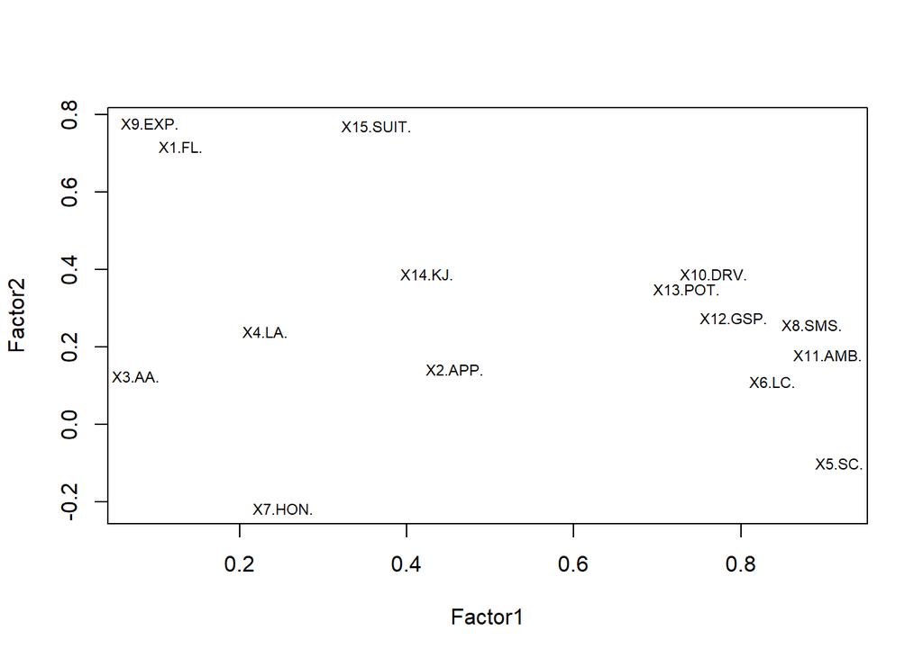

```r
load = fa1$loadings
plot(load, type = "n")
text(load, labels = colnames(app_s), cex = 0.7)
```

## fator rotation (인자 회전)

인자적재값의 구별이 쉬운 고유벡터를 찾아 회전

1. 직교 회전 (orthogonal ratation) : 회전된 인자들이 서로 상관되지 않도록 제약

varimax : 한 공통인자에 대해 각 변수가 가지는 인자적재값 제곱의 분산이 최대가 되도록 변환

```
       loadings matrix 각 열의 분산을 최대화 (가로 방향)
```

quartimax : 한 변수가 각각의 공통인자에서 차지하는 비중의 제곱에 대한 분산을 최대화

```
         loadings matrix 각 행의 분산을 최대화 (세로 방향)
```

2. 사각 회전 (oblique rotation) : 상관된 인자들을 허용

oblimin : 인자들 사이의 상관성 정도를 제어

promax : 회전에 의해 적재값을 어떤 승수로 올리는 방법. 인자들 사이에 낮은 상관성을 갖도록 함.

```r
fa1 = factanal(app, 4)   # default : varimax
fa2 = factanal(app, 4, rotation = "none")
print(fa2, digits = 2, sort = T)
```

```
##
## Call:
## factanal(x = app, factors = 4, rotation = "none")
##
## Uniquenesses:
##    X1.FL.   X2.APP.    X3.AA.    X4.LA.    X5.SC.    X6.LC.   X7.HON.   X8.SMS.
##      0.44      0.68      0.52      0.18      0.12      0.20      0.34      0.14
##   X9.EXP.  X10.DRV.  X11.AMB.  X12.GSP.  X13.POT.   X14.KJ. X15.SUIT.
##      0.36      0.23      0.14      0.15      0.09      0.00      0.25
##
## Loadings:
##           Factor1 Factor2 Factor3 Factor4
## X4.LA.     0.70            0.12    0.55
## X10.DRV.   0.67    0.54           -0.15
## X14.KJ.    0.99   -0.10
## X5.SC.     0.55    0.64   -0.40
## X6.LC.     0.60    0.65   -0.13
## X8.SMS.    0.63    0.64           -0.21
## X11.AMB.   0.62    0.65   -0.14   -0.19
## X12.GSP.   0.62    0.66            0.11
## X13.POT.   0.62    0.67    0.18    0.22
## X1.FL.     0.47            0.55   -0.18
## X9.EXP.    0.24    0.19    0.72   -0.19
## X15.SUIT.  0.44    0.37    0.62   -0.17
## X7.HON.    0.46           -0.27    0.60
## X2.APP.    0.33    0.43            0.14
## X3.AA.    -0.27    0.48    0.34    0.26
##
##                Factor1 Factor2 Factor3 Factor4
## SS loadings       5.02    3.45    1.65    1.03
## Proportion Var    0.33    0.23    0.11    0.07
## Cumulative Var    0.33    0.57    0.67    0.74
##
## Test of the hypothesis that 4 factors are sufficient.
## The chi square statistic is 84 on 51 degrees of freedom.
## The p-value is 0.00247
```

## 문제 풀어보기

```r
stock <- read.csv("stock_price.csv", header = T)
stock <- stock[, -1]
head(stock)
```

```
##     JPMorgan   Citibank WellsFargo RoyalDutchShell ExxonMobil
## 1  0.0130338 -0.0078431 -0.0031889      -0.0447693  0.0052151
## 2  0.0084862  0.0166886 -0.0062100       0.0119560  0.0134890
## 3 -0.0179153 -0.0086393  0.0100360       0.0000000 -0.0061428
## 4  0.0215589 -0.0034858  0.0174353      -0.0285917 -0.0069534
## 5  0.0108225  0.0037167 -0.0101345       0.0291900  0.0409751
## 6  0.0101713 -0.0121978 -0.0083768       0.0137083  0.0029895
```

적절한 공통인자의 수를 구하시오?

```r
fa01 <- factanal(stock, 2)

print(fa01, digits = 2, sort = T)
```

```
##
## Call:
## factanal(x = stock, factors = 2)
##
## Uniquenesses:
##        JPMorgan        Citibank      WellsFargo RoyalDutchShell      ExxonMobil
##            0.42            0.27            0.54            0.00            0.53
##
## Loadings:
##                 Factor1 Factor2
## JPMorgan        0.76
## Citibank        0.82    0.23
## WellsFargo      0.67    0.11
## RoyalDutchShell 0.11    0.99
## ExxonMobil      0.11    0.68
##
##                Factor1 Factor2
## SS loadings       1.72    1.51
## Proportion Var    0.34    0.30
## Cumulative Var    0.34    0.65
##
## Test of the hypothesis that 2 factors are sufficient.
## The chi square statistic is 1.97 on 1 degree of freedom.
## The p-value is 0.16
```

```r
    # common factor 갯수 = 2
```